# Democracy, Crime, and Equity in the U.S. States

Does state democratic backsliding track racial inequality in incarceration, and can felon re-enfranchisement undo it?

Author

Miura Meng

Published

June 16, 2026

Abstract

# 1 Question and contribution

Democracy, crime, and inequality all meet in one place: the criminal justice system. Democratic institutions decide who writes the rules and whether power stays in check. The justice system is where those rules reach individual people. Inequality, stated in statistical terms, is a difference in how the same system treats different groups. Put together, these three give one question. Is the health of a state’s democracy related to racial inequality in its prisons, and can a democratic reform change behavior on the ground?

The honest answer turns out to depend almost entirely on how the question is asked, and that dependence is the report’s real subject. I proceed in four steps, arranged so that each one tests, and then revises, the conclusion the previous step suggested. The first step measures inequality across states and finds a result that looks striking but proves fragile. The second replaces the cross-section with comparisons of each state against itself over time, which removes the fragility and isolates a smaller but more credible signal. The third asks whether states fall into distinct trajectory types, which adds texture while remaining descriptive. The fourth uses a natural experiment to ask, for once, a genuinely causal question. Read in sequence the steps form a single argument: the convenient cross-sectional story does not survive careful measurement, the careful version of it is real but modest, and the one place where cause can be tested directly shows a reform undone by its own fine print. The contribution is therefore less a new fact about democracy and crime than a disciplined account of how much the answer moves when the method improves.

# 2 Data and measures

Because the whole argument turns on measurement, it is worth being explicit at the start about the data and, above all, about what “inequality” will mean. The analysis combines three public datasets, each measured at the state-year level.

| Source | Unit | Coverage | Used for |
| --- | --- | --- | --- |
| State Democracy Index 2.0 (Grumbach & Bitton, UC Berkeley) | state-year | 2000 to 2023 | `democracy`, a latent score of democratic performance (higher is more democratic) |
| Vera Institute, Incarceration Trends | state-year | race-specific prison rates, 1990 to 2022 | Black and white prison rates per 100,000 |
| UF Election Lab (M. McDonald), Turnout 1980 to 2022 | state-year | even years | VAP turnout and counts of disenfranchised felons |

# 3 Measurement decides the answer

Begin with the question in its most direct form. If I average each state over 2016 to 2020 and plot the Black/White incarceration ratio against the State Democracy Index, more democratic states appear to have wider racial disparities. Taken at face value this is a provocative result, since it would imply that democratic health and racial fairness in punishment pull in opposite directions.

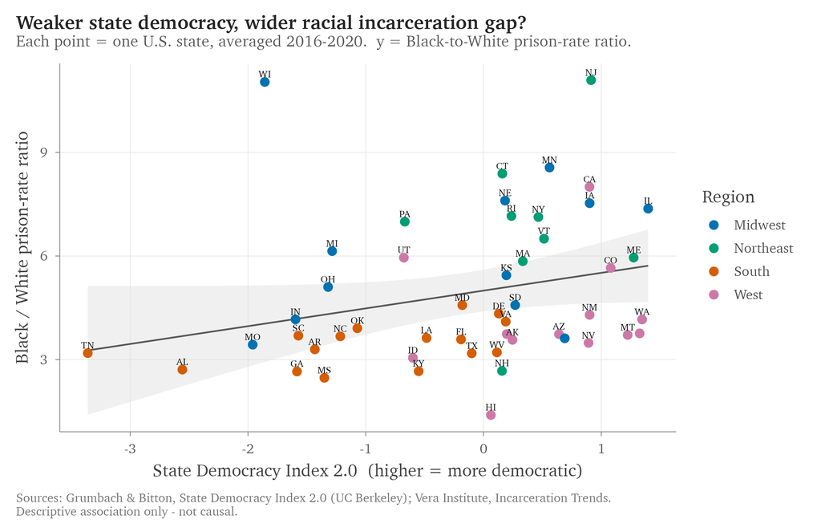

Across states, averaged over 2016 to 2020, the Black/White incarceration ratio rises with the State Democracy Index.

The result does not survive a change of measure, and seeing why is the whole point of this section. If I hold the democracy axis fixed and substitute four definitions of racial inequity, the correlation does not merely weaken. It changes sign.

**Recompute the four democracy and inequity correlations (2016 to 2020 cross-section)**

```r
win <- 2016:2020
st <- df |>
  filter(year %in% win, is.finite(black_prison_pop_rate),
         is.finite(white_prison_pop_rate), is.finite(democracy)) |>
  group_by(state_abbr) |>
  summarise(democracy  = mean(democracy),
            black_rate = mean(black_prison_pop_rate),
            white_rate = mean(white_prison_pop_rate), .groups = "drop") |>
  mutate(bw_ratio = black_rate / white_rate, gap = black_rate - white_rate)
cors <- sapply(c("bw_ratio","black_rate","white_rate","gap"),
               function(v) cor(st$democracy, st[[v]]))
tibble(`Inequity measure` = c("Black / White ratio","Absolute Black rate",
                              "Absolute White rate","Gap (Black minus White)"),
       `Correlation with State Democracy Index` = round(cors, 2)) |>
  kable(align = "lc")
```

| Inequity measure | Correlation with State Democracy Index |
| --- | --- |
| Black / White ratio | 0.26 |
| Absolute Black rate | -0.14 |
| Absolute White rate | -0.34 |
| Gap (Black minus White) | -0.04 |

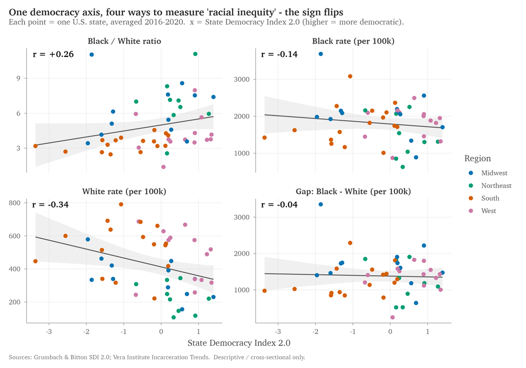

The same democracy axis against four measures of racial inequity. The sign of the relationship flips depending on the measure.

The mechanism is the white incarceration rate. More democratic states imprison far fewer white people (a correlation of about -0.34), and because the ratio divides the Black rate by the white rate, a smaller white rate inflates the ratio even when Black incarceration has not changed. The South shows a lower ratio not because it punishes Black and white residents more equally, but because it imprisons white residents at high rates too, which enlarges the denominator. Measured by the absolute Black rate, more democratic states are if anything slightly better, and the absolute gap is essentially flat. The lesson is uncomfortable but specific: the number reported most often, the ratio, is the one most likely to mislead, because it can move for reasons that have nothing to do with how Black residents are treated. And it has a direct methodological consequence. If a single cross-section can be turned upside down by the choice of denominator, then comparing different states is too weak an instrument for a question that sounds causal. The natural correction is to stop comparing states with one another and start comparing each state with itself.

# 4 Following each state over time

Comparing states with one another mixes democracy together with everything else that makes states differ: region, demographics, history, and the local economy. The previous section showed how badly that mixing can distort the answer. A cleaner question is longitudinal. When a given state’s democracy rises or falls, does its incarceration move with it? Because each state then serves as its own control, the fixed differences that contaminated the cross-section drop out of the comparison.

To make this precise I split the democracy score into two parts. The first is each state’s long-run average, which carries the between-state variation that the earlier figures relied on. The second is each year’s deviation from that average, which carries the within-state variation that tracks change over time. This within/between split follows Mundlak (1978). I then fit a linear mixed model with a random intercept for each state and a common year trend, so that the two kinds of variation are estimated side by side rather than confused with each other.

**Fit the three within and between mixed models (lme4)**

```r
panel <- df |>
  filter(is.finite(bw_ratio), black_prison_pop_rate > 0, white_prison_pop_rate > 0,
         is.finite(democracy)) |>
  group_by(state_abbr) |>
  mutate(dem_between = mean(democracy), dem_within = democracy - dem_between, n = n()) |>
  ungroup() |> filter(n >= 10) |> mutate(year_c = year - 2011)

outc <- c("log(Black/White ratio)" = "log(bw_ratio)",
          "log(Black rate)"        = "log(black_prison_pop_rate)",
          "log(White rate)"        = "log(white_prison_pop_rate)")
res <- lapply(names(outc), function(nm) {
  m  <- lmer(as.formula(paste0(outc[[nm]],
              " ~ dem_within + dem_between + year_c + (1 | state_abbr)")), data = panel)
  co <- summary(m)$coefficients
  tibble(Outcome = nm,
         `Within-state`  = round(co["dem_within","Estimate"], 3),
         `Between-state` = round(co["dem_between","Estimate"], 3),
         `Year trend`    = round(co["year_c","Estimate"], 3))
}) |> bind_rows()
kable(res, align = "lccc")
```

| Outcome | Within-state | Between-state | Year trend |
| --- | --- | --- | --- |
| log(Black/White ratio) | 0.012 | 0.183 | -0.026 |
| log(Black rate) | -0.040 | -0.030 | -0.027 |
| log(White rate) | -0.052 | -0.213 | -0.001 |

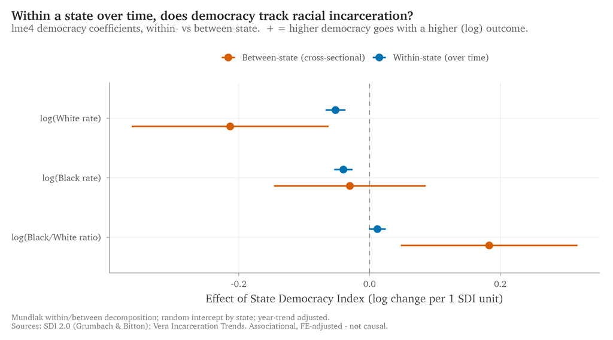

Within-state versus between-state democracy coefficients. The cross-sectional ratio effect (orange) disappears within states (blue).

# 5 A typology of state trajectories

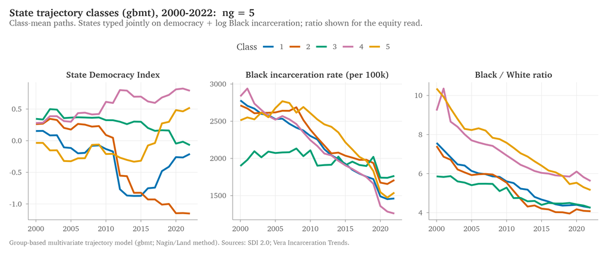

Five state trajectory classes from the gbmt model. Each line is a class-mean path for democracy, Black incarceration, and the Black/White ratio.

The classes line up along a single spectrum, which is what makes them interpretable rather than arbitrary (means shown for 2000 and 2022).

| Class | Example states | Democracy | Black rate | Reading |
| --- | --- | --- | --- | --- |
| 4 | CA, NY, NJ, MA, CT, WA | 0.28 → 0.79 | 2835 → 1260 | grew more democratic, decarcerated the most |
| 5 | FL, IL, PA, VA, MN | -0.04 → 0.52 | 2513 → 1541 | grew more democratic, ratio converged |
| 1 | GA, MD, MI, OH, TX | 0.15 → -0.21 | 2780 → 1462 | slight decline, still large decarceration |
| 3 | AR, ID, MT, NE, WV | 0.35 → -0.07 | 1899 → 1765 | stuck: the Black rate barely moved |
| 2 | AL, MS, TN, OK, WI | 0.26 → -1.15 | 2713 → 1710 | backslid the most; the white rate rose |

# 6 A causal test: Florida’s Amendment 4

With only one treated state, the appropriate tool is synthetic control (Abadie, Diamond, and Hainmueller, 2010). The method builds a “synthetic Florida” from a weighted combination of states that did not change their felon-voting laws, chosen so that the combination reproduces Florida’s turnout history before the reform, and then reads the reform’s effect as the gap that opens afterward. I use VAP turnout as the outcome, because its denominator is the voting-age population and therefore does not move mechanically when people are re-enfranchised. A placebo, or permutation, test provides inference by asking how unusual Florida’s gap is against the same gaps computed for every donor state.

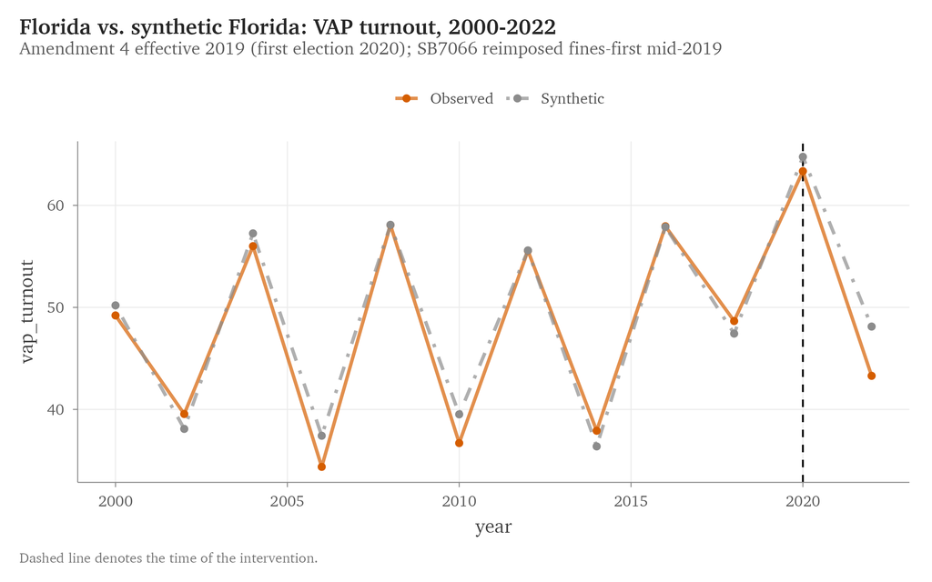

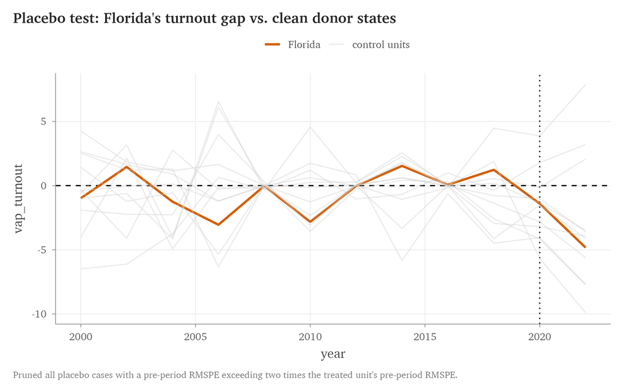

The pre-reform fit is close, with a 2016 gap of only 0.07 points, which gives the comparison credibility. After the reform the gaps are -1.4 points in 2020 and -4.8 in 2022, both negative rather than positive, and the placebo test returns a p-value of about 0.14, which means Florida is not unusual among the donor states. Amendment 4 produced no detectable increase in turnout.

A null result is only worth reporting if we can say why it happened, and here the reason is visible in the same data. The reform barely took effect. Florida’s disenfranchised share fell only from 1.25 percent of the voting-age population in 2018 to 1.16 percent in 2020 and 1.14 percent in 2022, a nearly flat line rather than the steep drop that re-enfranchising 1.4 million people would imply. The explanation is that a second law passed in mid-2019, SB7066, required people to pay all outstanding court fines and fees before regaining the vote. That payment requirement works as a wealth test on the franchise, and it falls hardest on poor and disproportionately Black Floridians. The null is therefore not the absence of a story but the signature of one: a democratic expansion was largely cancelled by a second, regressive measure before it could change behavior. This is the cleanest causal statement the report can make, and it closes the arc the earlier sections opened. Where the cross-section offered a striking but artifactual link, and the within-state and trajectory analyses offered a real but modest one, the single deliberate intervention available to test shows that even a large and direct expansion of democratic rights can come to little once its implementation is undone.

# 7 Limitations

The argument depends on taking each step’s weaknesses seriously, so the main ones belong in the open rather than in a footnote.

Aggregate turnout is a blunt instrument. Even a fully effective Amendment 4 (about 8 percent of the voting-age population, most of whom never register or vote) might move statewide turnout by less than one point, below what this design can detect. The null therefore means there was no large aggregate effect, not that re-enfranchisement is pointless, and a sharper test would follow the formerly incarcerated individually in voter files.

The cross-sectional, mixed-model, and trajectory sections are observational rather than experimental. The mixed models adjust for fixed differences between states but do not identify a cause, and the trajectory classes are descriptive and confounded with region. They support the framing of the question, not a causal answer to it.

State democracy and incarceration are themselves estimated quantities. A fuller treatment would compare alternative measures and carry the resulting estimation error through the analysis.

The synthetic control rests on a single treated state, an imperfect pre-period fit in midterm years, a small pool of clean donor states that limits statistical power, and a 2020 treatment year that coincided with the pandemic turnout surge. The placebo p-value should be read with that limited power in mind.

# 8 What this adds, and what comes next

The four steps make one argument, and it is worth stating plainly. The relationship between state democracy and racial inequality in incarceration is weaker and far more measurement-dependent than a single cross-section suggests. The ratio that is reported most often points the wrong way for a mechanical reason. The credible link, visible only within states over time, is real but small beside a national decline in incarceration. And the one reform clean enough to test causally left no mark on turnout because a second law neutralized it. None of these is a breakthrough on its own. Together they make a more useful point: on a question like this the method is not a technicality but the finding itself, and disciplined measurement and design repeatedly overturn the convenient answer. That is the habit the analysis was built to demonstrate, and the whole pipeline is reproducible from raw data to figures.

Three extensions would sharpen the argument, each aimed at the weakest link above. Individual voter-file data would give a far more sensitive test of Amendment 4 than aggregate turnout, by following the formerly incarcerated themselves rather than the entire electorate. A staggered design across the many states that changed felon-voting rules between 2016 and 2022 would turn a single case into many and improve both statistical power and external validity. And alternative trajectory estimators with bootstrap resampling would show how firm the five-class typology really is. Each of these tightens a specific claim the report has deliberately tried not to overstate.

# 9 References

## 9.1 Data sources

Grumbach, J. M., & Bitton, F. (2024). *State Democracy Index 2.0* [Data set]. Democracy Policy Lab, University of California, Berkeley. https://democracypolicylab.berkeley.edu/state-democracy-index/

McDonald, M. P. (2023). *United States Elections Project: Voter Turnout Data, 1980–2022* [Data set]. UF Election Lab, University of Florida. https://election.lab.ufl.edu/voter-turnout/

Vera Institute of Justice. (2024). *Incarceration Trends* [Data set]. https://github.com/vera-institute/incarceration-trends

## 9.2 Methods and software

Abadie, A., Diamond, A., & Hainmueller, J. (2010). Synthetic Control Methods for Comparative Case Studies: Estimating the Effect of California’s Tobacco Control Program. *Journal of the American Statistical Association, 105*(490), 493–505.

Bates, D., Mächler, M., Bolker, B., & Walker, S. (2015). Fitting Linear Mixed-Effects Models Using lme4. *Journal of Statistical Software, 67*(1), 1–48.

Dunford, E. (2023). *tidysynth: A Tidy Implementation of the Synthetic Control Method* [R package]. https://CRAN.R-project.org/package=tidysynth

Magrini, A. (2022). *gbmt: Group-Based Multivariate Trajectory Modeling* [R package]. https://CRAN.R-project.org/package=gbmt

Mundlak, Y. (1978). On the Pooling of Time Series and Cross Section Data. *Econometrica, 46*(1), 69–85.

Nagin, D. S., & Land, K. C. (1993). Age, Criminal Careers, and Population Heterogeneity: Specification and Estimation of a Nonparametric, Mixed Poisson Model. *Criminology, 31*(3), 327–362.

R Core Team. (2025). *R: A Language and Environment for Statistical Computing* (version 4.5.2). R Foundation for Statistical Computing. https://www.R-project.org/

## 9.3 Policy and other works

Florida Department of State, Division of Elections. (2018). *Amendment 4: Voting Restoration Amendment* (Florida Constitution, Art. VI, § 4).

Florida Legislature. (2019). *Senate Bill 7066.*

Grumbach, J. M. (2022). *Laboratories against Democracy: How National Parties Transformed State Politics*. Princeton University Press.

Grumbach, J. M. (2023). Laboratories of Democratic Backsliding. *American Political Science Review, 117*(3), 967–984.

The Sentencing Project. (2024). *Locked Out 2024: Four Million Denied Voting Rights Due to a Felony Conviction.*

## 10 Reproducibility

Every figure and number in this report is produced by the scripts in `R/`, run in order. All analyses use R (R Core Team, 2025) with the packages lme4 (Bates et al., 2015), gbmt (Magrini, 2022), and tidysynth (Dunford, 2023).

| Script | Produces |
| --- | --- |
| `01_load_merge.R` | the merged state-year dataset (`data/state_dem_incarceration.rds`) |
| `02_first_plot.R` | cross-section of democracy against the Black/White ratio |
| `03_equity_measures.R` | the four-measure comparison |
| `04_within_state_models.R` | the within and between mixed models, with figure |
| `05_gbtm_trajectories.R` | the trajectory typology, with figure |
| `06_causal_amendment4.R` | the Florida synthetic control, with figures |